# Extract and aggregate gridded datasets with R

This [R Markdown](http://rmarkdown.rstudio.com) Notebook has two distinct goals:

- show how climatic data stored as ncdf format can easily be extracted in R;
- illustrate how gridded data can be aggregated at a given administrative level.

# Datasets

For this purpose, the gridded daily weather data for 1950-2015 available from the [E-OBS repository](http://www.ecad.eu/download/ensembles/download.php) (v13.1 at 25 km x 25km horizontal resolution) is used (Haylock et al., 2008)[^1].

The code chunk below reads the daily maximum temperature (**tx**) records from E-OBS and creates a RasterBrick i.e. a multi-layer raster object:

```r
require(raster)
require(magrittr)
eobs.path <- "~/Desktop/EOBS/%s_0.25deg_reg_v13.1.nc"
tmax.nc <- sprintf(eobs.path, 'tx') %>%
        brick()
tmax.nc
```

```
class       : RasterBrick
dimensions  : 201, 464, 93264, 24106  (nrow, ncol, ncell, nlayers)
resolution  : 0.25, 0.25  (x, y)
extent      : -40.5, 75.5, 25.25, 75.5  (xmin, xmax, ymin, ymax)
coord. ref. : +proj=longlat +datum=WGS84 +ellps=WGS84 +towgs84=0,0,0
data source : /Users/tklein/Desktop/EOBS/tx_0.25deg_reg_v13.1.nc
names       : X1950.01.01, X1950.01.02, X1950.01.03, X1950.01.04, X1950.01.05, X1950.01.06, X1950.01.07, X1950.01.08, X1950.01.09, X1950.01.10, X1950.01.11, X1950.01.12, X1950.01.13, X1950.01.14, X1950.01.15, ...
Date        : 1950-01-01, 2015-12-31 (min, max)
varname     : tx
```

Plotting the first record (1950-01-01):

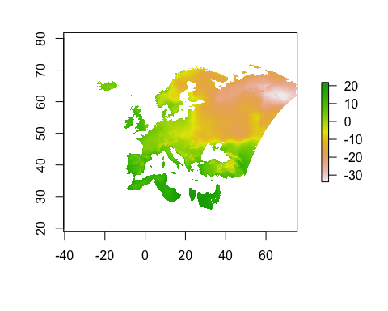

```r
plot(tmax.nc[[1]])
```

The analysis is performed for France at the departement level (admin 2). The shapefile (shp) comes from the [Global Administrative Areas | Boundaries without limits](http://www.gadm.org/).

```r
ISO <- 'FRA'
shp <- getData('GADM', country = ISO, level = 2)
shp
```

```
class       : SpatialPolygonsDataFrame
features    : 96
extent      : -5.143751, 9.560416, 41.33375, 51.0894  (xmin, xmax, ymin, ymax)
coord. ref. : +proj=longlat +datum=WGS84 +no_defs +ellps=WGS84 +towgs84=0,0,0
variables   : 12
names       : OBJECTID, ID_0, ISO, NAME_0, ID_1,      NAME_1, ID_2,   NAME_2,      TYPE_2,  ENGTYPE_2, NL_NAME_2,   VARNAME_2
min values  :        1,   79, FRA, France,    1,      Alsace,    1,      Ain, Département, Department,        NA, Alto Garona
max values  :       96,   79, FRA, France,   22, Rhône-Alpes,   96, Yvelines, Département, Department,        NA,     Vendéia
```

# Grid creation

The next step is the creation of the grid for E-OBS. Therefore, a mask with non NaNs is created and extracted for locations within the shp for France. Then, coordinates are extracted from the mask and saved as *SpatialPoints*.

[figure not shown]

```r
require(dplyr)
mask.EOBS <- !is.na(tmax.nc[[1]]) %>%
        crop(shp) %>%
        mask(shp)
grid.EOBS <- coordinates(mask.EOBS) %>%
    as.data.frame() %>%
    mutate(keep = getValues(mask.EOBS)) %>%
    filter(keep) %>%
    SpatialPoints()
projection(grid.EOBS) <- projection(shp)
plot(grid.EOBS, col = 'red')
#plot(shp, add = T)
```

A lookup table is then created in which the admin levels 1 and 2 of each grid point is stored:

```r
lookup <- over(grid.EOBS, shp) %>%
    tbl_df()
lookup
```

```
Source: local data frame [1,019 x 12]

   OBJECTID  ID_0   ISO NAME_0  ID_1             NAME_1  ID_2        NAME_2      TYPE_2
      (dbl) (dbl) (chr)  (chr) (dbl)              (chr) (dbl)         (chr)       (chr)
1        70    79   FRA France    17 Nord-Pas-de-Calais    70 Pas-de-Calais Département
2        70    79   FRA France    17 Nord-Pas-de-Calais    70 Pas-de-Calais Département
3        69    79   FRA France    17 Nord-Pas-de-Calais    69          Nord Département
4        70    79   FRA France    17 Nord-Pas-de-Calais    70 Pas-de-Calais Département
5        70    79   FRA France    17 Nord-Pas-de-Calais    70 Pas-de-Calais Département
6        70    79   FRA France    17 Nord-Pas-de-Calais    70 Pas-de-Calais Département
7        70    79   FRA France    17 Nord-Pas-de-Calais    70 Pas-de-Calais Département
8        69    79   FRA France    17 Nord-Pas-de-Calais    69          Nord Département
9        69    79   FRA France    17 Nord-Pas-de-Calais    69          Nord Département
10       69    79   FRA France    17 Nord-Pas-de-Calais    69          Nord Département
..      ...   ...   ...    ...   ...                ...   ...           ...         ...
Variables not shown: ENGTYPE_2 (chr), NL_NAME_2 (lgl), VARNAME_2 (chr)
```

# Time Series Extraction

The extraction of grid time series from a RasterBrick is fairly straighforward in R, by subsetting the RasterBrick with a SpatialPoints object (in this case the grid definition). This operation can be quite time consuming. The resulting data structure is a matrix, which is then transposed and converted to a data.frame (long format).

```r
require(tidyr)
require(stringr)
require(lubridate)
tmax.ts <- tmax.nc[grid.EOBS] %>%
        t %>%
        as.data.frame() %>%
        mutate(date = row.names(.) %>% str_sub(start = 2) %>% ymd) %>%
        tbl_df %>%
        gather(key = id, value = tmax, -date) %>%
        mutate(id = id %>% str_sub(start = 2) %>% as.integer())
```

# Use Case

This section contains a brief analysis of the number of critical days ($T_\mathit{max} > 34^\circ C$) per departement. First, the departement is added to each record (*lookup.adm2*).

```r
lookup.adm2 <- dplyr::select(lookup, NAME_2) %>%
    rename(departement = NAME_2) %>%
    mutate(id = row.names(.) %>% as.integer())

tmax.ts.lookup <- tmax.ts %>%
    mutate(year = year(date),
           month = month(date)) %>%
    left_join(lookup.adm2)
```

```r
threshold <- 34.  # degC

crit.days <- tmax.ts.lookup %>%
    group_by(year, id, departement) %>%
    summarise(N = sum(tmax > threshold)) %>%
    ungroup() %>%
    group_by(year, departement) %>%
    summarise(N.avg = mean(N))
```

The map below shows the average number of critical days per departement:

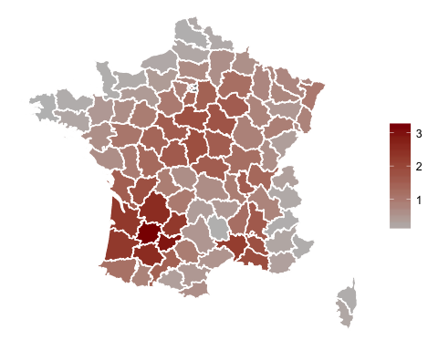

```r
require(ggplot2)
require(maptools)
shp.ggplot <- shp %>%
    fortify(region = 'NAME_2') %>%
    rename(departement = id)
dat.plot <- crit.days %>%
    group_by(departement) %>%
    summarise(N.avg = mean(N.avg)) %>%
    right_join(shp.ggplot)
ggplot(dat.plot) +
    aes(long, lat, group = group, fill = N.avg) +
    geom_polygon() +
    geom_path(color = "white") +
    scale_fill_gradient(low = 'grey', high = 'darkred') +
    theme_void()
```

The histogram below shows the distribution of critical days:

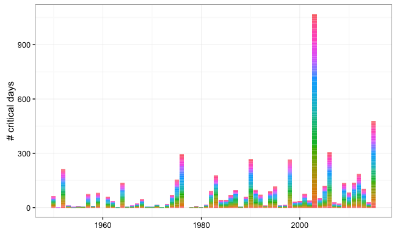

```r
ggplot(crit.days,  aes(x = year, y = N.avg, fill = departement)) +
    geom_bar(stat ="identity") +
    theme_bw() +
    theme(legend.position = "none") +
    xlab('') +
    ylab('# critical days')
```

[^1]: Haylock, M.R., N. Hofstra, A.M.G. Klein Tank, E.J. Klok, P.D. Jones, M. New. 2008: A European daily high-resolution gridded dataset of surface temperature and precipitation. J. Geophys. Res (Atmospheres), 113.